# noise

### How to cascade incoherent noise sources

The probality denisty function (PDF) of normal random variable with variance $var(X) = \sigma^2$ and expectation (mean) of $\mu$ is defined as: $$f_{pdf}(x) = \frac{1}{\sqrt{2\pi \sigma^2}} \; exp\left(-\frac{(x-\mu)^2}{2\sigma^2}\right)$$ The standard deviation is denoted by $\sigma$, and is equal to $\sqrt{var(X)}$ (pg 153 of Bertsekas e2)

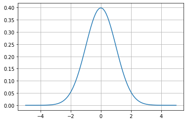

```
(0.9999999999999997, 1.0178191437091558e-08)
```

```python
import numpy as np
import matplotlib.pyplot as plt
import scipy.integrate as integrate

variance = 1
mean = 0

x = np.linspace(-5,5, 100)
pdf_x = (1/np.sqrt(2*np.pi*variance))*np.exp((-(x-mean)**2)/(2*variance))
plt.plot(x, pdf_x)
plt.grid(True)
plt.show()

def integrand(x, mean, variance):
    return (1/np.sqrt(2*np.pi*variance))*np.exp((-(x-mean)**2)/(2*variance))

result = integrate.quad(integrand, -np.inf, np.inf, args=(mean, variance))
result
```

The variance $var(X)$ is defined as: $$var(X) = \mathbf{E}[(X-\mathbf{E}[X])^2]$$ The mean (expectation) of a continuous random variable is defined as: $$ \mathbf{E}[X] = \int_{-\infty}^{\infty}{x \, f_x (x) \; dx}$$ This definition for $\mathbf{E}[X]$ only works because the integral of a PDF always adds up to 1, but it is essentially just taking the average of a function.

Now consider that this random normal PDF is used to generate a random value over and over producing a series of random numbers over a time interval. We'll call this random number generator $f_r(t)$ (which will produce numbers centered around the mean) and we'll call the sequence $p(t)$ since it is function of time. If we take enough samples, the average value of all these numbers will converge on the PDF mean $\mu$. The variance will also converge on the same $\sigma^2$ of the PDF. If we assume that the mean is zero, the variance equation simplifies to: $$var(X) = \mathbf{E}\left[X^2\right]$$

Since we are assuming each number is being produced over a time interval the overall variance of the sequence is:

$$p(t)_{var} = \frac{1}{T}\int_{0}^{T}{f_x(t)^2 \; dt}$$

Which is simply taking the average of the squared values produced by the random number generator.

The code below generates a sequence of random numbers each with a normal probalility density function and computes the mean and average variance of the sequence.

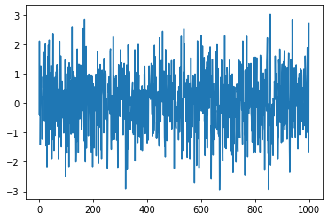

```
mean = 0.049, variance = 1.020
```

```python
variance = 1.0
mean = 0

x = np.arange(0,1000)
random_sequence = np.random.normal(mean, np.sqrt(variance), 1000)
plt.plot(x, random_sequence)
plt.show()
mean_actual = np.average(random_sequence)
var_actual = np.average(random_sequence**2)
print('mean = {:.3f}, variance = {:.3f}'.format(mean_actual, var_actual))
```

Now say we had a radom noise source that produced small random voltages just like the sequence above. Now what if we had two of them in series? What would the resulting voltage be? It takes some pretty heavy duty math to prove the following:

If the normal random variables $X$ and $Y$ are independent (uncorellated), then their sum $(X+Y)$ is also a normal random variable with mean $(\mu_x+\mu_y)$ and variance $\sigma^2_x+\sigma^2_y$ (pg 216 Bertsekas)

Lets plot and compute the variance and mean of the sum of two of these sequences and see if this holds:

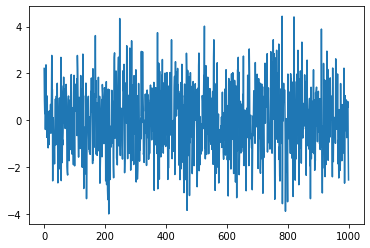

```
mean = -0.010, variance = 2.056
```

```python
variance = 1
mean = 0
rand1 = np.random.normal(mean, np.sqrt(variance), 1000)
rand2 = np.random.normal(mean, np.sqrt(variance), 1000)
sum12 = rand1 + rand2
plt.plot(x, sum12)
plt.show()
mean_actual = np.average(sum12)
var_actual = np.average(sum12**2)
print('mean = {:.3f}, variance = {:.3f}'.format(mean_actual, var_actual))
```

This will even hold for any number of random variables being added together. The variance of the output will converge to the sum of the variances of each variable. If we are strictly talking about random voltages, there is an interesting connection between the variance of the random sequence and the RMS voltage. RMS voltage is usually thought of as being $1/\sqrt{2}$ times the peak voltage. That is actually only a special case of RMS as it applies to purely sinusoidal signals. If the waveform is not sinusoidal, then you have to go back to the general defition of RMS which is:

$$f_{rms} = \sqrt {{1 \over {T}}{\int _{0}^{T}{f(t)}^{2}\,dt}}$$

RMS stands for root mean square which is exactly what this equation is. We are squaring each value, averaging them, then taking the squre root. If you remember above we found that the total variance of the sequence could be found by: $$p(t)_{var} = \frac{1}{T}\int_{0}^{T}{f_x(t)^2 \; dt}$$

Since the variance is equal to: $$var(X) = \sigma^2$$ $$\sigma = \sqrt {{1 \over {T}}{\int _{0}^{T}{f_x(t)}^{2}\,dt}}$$ $$\sigma = f_{rms}$$

The RMS voltage of a random voltage waveform with zero mean is equal to the standard deviation.

This means that we now have a very easy way to compute the output of a sum of series noise sources. Since we know that the output waveform will have a variance of the sum of the waveforms being combined: $$ var_{output} = var_1 + var_2 $$ $$ \sigma_{output}^2 = \sigma_1^2 + \sigma_2^2$$

We know that the RMS voltage of the output will be: $$ v_{O,rms}^2 = v_{1,rms}^2 + v_{2,rms}^2 $$ $$ v_{O,rms} = \sqrt{v_{1,rms}^2 + v_{2,rms}^2} $$

Essentially, incoherent noise sources add in power, not in voltage.

If the noise sources are coherent then the RMS voltages add like you would exepct: $$ v_{O,rms} = v_{1,rms} + v_{2,rms} $$

Note that for noise sources, the RMS voltage is really the best way to characterize the noise since peak voltage is meaningless for noise. The peak could be arbitrarily high but doesn't characterize the power of the singal.

What if we had parallel noise sources instead of series? In that case the random noise currents would add (Kirchoff's current law) instead of the voltage. If the sources are independent: $$ i_{O,rms}^2 = i_{1,rms}^2 + i_{2,rms}^2 $$

And if not: $$ i_{O,rms} = i_{1,rms} + i_{2,rms} $$

The RMS current is related to the RMS voltage by: $$i_{rms} = \frac{v_{rms}}{R}$$ Where $R$ is the resistance of the component generating noise.

### Noise Power

If $v_{rms}$ and $i_{rms}$ are purely in phase (like in a resistor) then finding the power is straight-foward. Electrical power is defined as: $$P = V*I$$

When considering noise we aren't interested in the instantaneous noise power, but in the average over time: $$ P_{avg} = \frac{1}{T}\int_0^T{V*I \; dt}$$

Since we are assuming the power is inphase: $$I = \frac{V}{R}$$ $$ P_{avg} = \frac{1}{T}\int_0^T{\frac{V^2}{R} \; dt}$$ $$ P_{avg} = \frac{1}{TR}\int_0^T{V^2 \; dt}$$

Remember above we found that the variance of a sequence of random numbers was: $$p(t)_{var} = \frac{1}{T}\int_{0}^{T}{f_x(t)^2 \; dt}$$

This means we can rewrite the average power integral as: $$ P_{avg} = \frac{var(V)}{R} = \frac{\sigma_v^2}{R}$$

And since the standard deviation is equal to the RMS voltage: $$P_{avg} = \frac{v_{rms}^2}{R}$$

This is shown below:

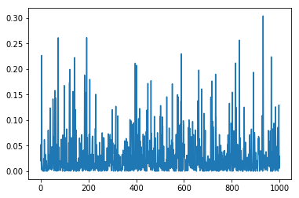

```
avg power: 0.030
0.03
```

```python
variance = 1.5
mean = 0
R = 50
v1 = np.random.normal(mean, np.sqrt(variance), 1000)
i1 = v1/50
x = np.arange(0,1000)
#plt.plot(x, v1)
pwr = v1*i1
plt.plot(x, pwr)
plt.show()
print('avg power: {:.3f}'.format(np.average(pwr)))
print(variance/50)
```

At microwave frequencies, the RMS noise voltage produced by a resistor can be modeled by: $$ v_{rms} = \sqrt{4kTBR} $$ Where $T$ is the temperature in kelvin, $B$ is the bandwidth of the system, and $k$ is the boltzman constant.

The maximum power than can be transfered to a load (which is a conjugate matched load, another resistor of the same value $R$). This creates a voltage divider with a factor of 2:

$$V_{rms, load} = \frac{\sqrt{4kTBR}}{2}$$

This is the rms voltage across the load. With this we can also find the average power delivered to the load: $$P_{load} = \frac{V_{rms,load}^2}{R} = \frac{4kTBR}{4R} = kTB $$

We could also model the noise source as a current source with the source resistor in parallel: $$I_n = \frac{V_n}{R} = \frac{\sqrt{4kTBR}}{R} = \sqrt{\frac{4kTB}{R}}$$

### Old stuff

If the variables are corellated (at least to some degree), then the variance is: $$var(X+Y) = var(X) + var(Y) + 2*cov(X,Y)$$ Where $cov$ is the covariance of the two variables: $$ cov(X,Y) = \boldsymbol{E}\left[(X-\boldsymbol{E}[X])(Y-\boldsymbol{E}[Y])\right]$$ http://cas.ee.ic.ac.uk/people/dario/files/E302/2-noise.pdf

Since we have a long series of independent random variables all with the same mean and variance, intuitively the average value over this sequence will be the mean, $\mu = \mathbf{E}[X]$. Since we are not summing these variables, each is defined uniquely for a moment in time, the average variance of the sequence will converge on $\sigma^2$. A more general equation to find an average over a finite range: $$\mu={\frac {1}{b-a}}\int _{a}^{b}f(x)\,dx.$$ If the mean is 0, the variance reduces to: $$var(X) = \mathbf{E}\left[X^2\right] = {\frac {1}{b-a}}\int _{a}^{b}f_{x}\left(x^2\right)\,dx.$$